# Motivation for using zero-inflated beta-binomial model for regression

SK

June 25, 2019

# 1 Introduction

When we analyze repertoires of health-challenged individuals, we are allowed to sample a limited amount of cells from each patient. This leads to additional variability in the data, which is manifested by over-dispersion of gene usage within a biological condition, or by misdetection (zero-inflation) of genes which are systematically used at a low probability by the rearrangement process.

Bayesian hierarcical models for ZIBB regression represent a solution to this problem. The ZIBB model describes the data using two components: 1) zero generating process that accounts for the excess zeros; 2) beta-binomial process that can also account for over-dispersion. In this vignette we show the pitfalls of not accounting for the over-dispersion while evaluating differential gene usage.

The data used in this vignette is taken from Case Study I (explained in vignette ‘IgUsageCaseStudies’). We analyze the data with the following three models and compare the results:

- Binomial (B)
- Beta-binomial (BB)
- Zero-inflated beta-binomial (ZIBB)

See vignette ‘ModelOVerview’ for details about each model. To see an example where ZIBB is not preferred to BB, please see the following vignettes:

- ‘ModelComparison_Alakazam’
- ‘ModelComparison_CDR3Charge’
- ‘ModelComparison_HIV’

# 2 Comparison of coefficients for differential gene usage

Comparisons:

- ZIBB vs BB
- ZIBB vs B
- BB vs B

Note that the binomial model is too optimistic, i.e. it over-estimates the coefficient of differnetial gene usage. This because the binomial model ignores the over-dispersion in the data. There is a lot of discordance between models ZIBB and BB as well (many genes are shown far away from the diagnoal). Next, lets look at the 10 genes which are far away from the diagnoal in the comparison between ZIBB and BB.

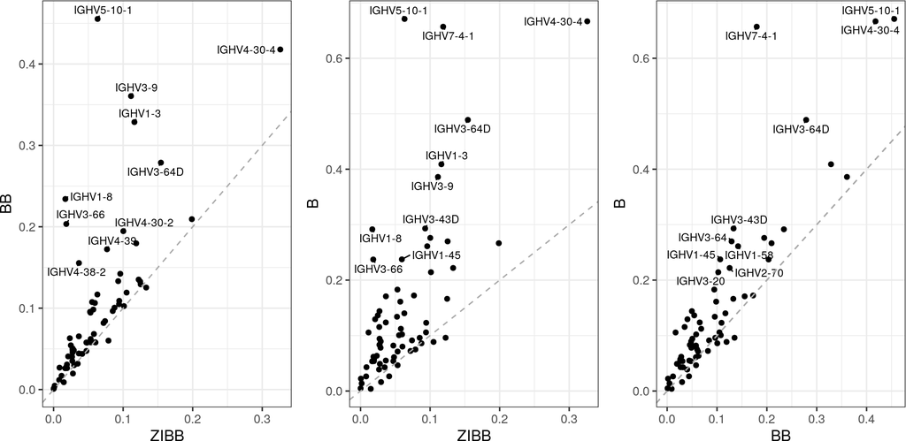

# 3 Reality Check

The discordant genes have gene usage which is inflated by zeros, i.e. the distribution of gene usage is made up of two components, namely a zero component and non-zero component.

The models B and BB handle the data as originating from one component. Their resulting estimate of gene usage are a compromise between both components. The ZIBB model does not suffer from this problem and correctly estimates the mean usage in such a case.

Noteable examples:

- IGHV3-9
- IGHV3-66
- IGHV5-10-1

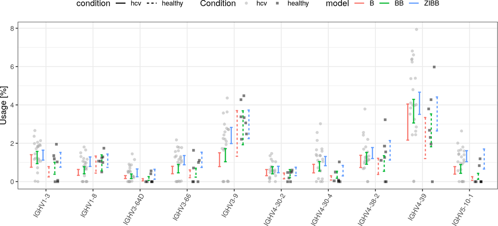